# Machine Learning - Wine Quality

# Group No : 271

# R A Bharat | Kulkarni Nishant Mohanrao | S Sumalatha

```python
#Read Files
import sys
import pandas as pd
import seaborn as sns
from datetime import datetime
import matplotlib.pyplot as plt
from sklearn.model_selection import KFold
from sklearn.preprocessing import StandardScaler
```

**Common function definition**

```python
def conf_matrix(act, pred):
    mat = np.zeros((2,2))
    mat[0][0] = np.sum([pred[i]==act[i] and act[i]==1 for i in range(len(act))]).astype(int)
    mat[1][1] = np.sum([pred[i]==act[i] and act[i]==0 for i in range(len(act))]).astype(int)
    mat[0][1] = np.sum([pred[i]!=act[i] and act[i]==0 for i in range(len(act))]).astype(int)
    mat[1][0] = np.sum([pred[i]!=act[i] and act[i]==1 for i in range(len(act))]).astype(int)
    return mat


def sigmoid(z):
    return (1+np.exp(-z))**(-1)



def cost_func(theta, X, Y):

    h = sigmoid(np.dot(X, theta))
    print("h:",h)
    N = len(X)
    print("N:",N)
    pred_1 = Y*np.log(h)
    pred_0 = (1-Y)*np.log(1-h)
    J = -(pred_0+pred_1)/N
    return J



def grad_descent(X, Y, a=0.04, epochs=7000):

    theta = np.random.rand(X.shape[1])
    N = len(X)
    J = [cost_func(theta, X, Y)]

    for i in range(epochs):
        y_cap = sigmoid(np.dot(X, theta))
        theta -= a * np.dot(X.T, (y_cap - Y))/N
        J.append(cost_func(theta, X, Y))
    return J, theta



def predict(X, theta):

    z = np.dot(X, theta)
    p = [round(i) for i in sigmoid(z)]
    return p
```

1. Data Visualization and Exploration

**1a. display dataset**

```python
wine_df = pd.read_csv('winequality-red.csv')
print("Features of Wine Quality file ")
wine_df.head()
```

```
Features of Wine Quality file
```

|  | fixed acidity | volatile acidity | citric acid | residual sugar | chlorides | free sulfur dioxide | total sulfur dioxide | density | pH | sulphates | alcohol | quality |
| --- | --- | --- | --- | --- | --- | --- | --- | --- | --- | --- | --- | --- |
| 0 | 7.4 | 0.70 | 0.00 | 1.9 | 0.076 | 11.0 | 34.0 | 0.9978 | 3.51 | 0.56 | 9.4 | 5 |
| 1 | 7.8 | 0.88 | 0.00 | 2.6 | 0.098 | 25.0 | 67.0 | 0.9968 | 3.20 | 0.68 | 9.8 | 5 |
| 2 | 7.8 | 0.76 | 0.04 | 2.3 | 0.092 | 15.0 | 54.0 | 0.9970 | 3.26 | 0.65 | 9.8 | 5 |
| 3 | 11.2 | 0.28 | 0.56 | 1.9 | 0.075 | 17.0 | 60.0 | 0.9980 | 3.16 | 0.58 | 9.8 | 6 |
| 4 | 7.4 | 0.70 | 0.00 | 1.9 | 0.076 | 11.0 | 34.0 | 0.9978 | 3.51 | 0.56 | 9.4 | 5 |

**1b. Describe Wine dataset**

```python
#Statistical Description of the data

print(wine_df.describe())
```

```
       fixed acidity  volatile acidity  citric acid  residual sugar  \
count    1599.000000       1599.000000  1599.000000     1599.000000
mean        8.319637          0.527821     0.270976        2.538806
std         1.741096          0.179060     0.194801        1.409928
min         4.600000          0.120000     0.000000        0.900000
25%         7.100000          0.390000     0.090000        1.900000
50%         7.900000          0.520000     0.260000        2.200000
75%         9.200000          0.640000     0.420000        2.600000
max        15.900000          1.580000     1.000000       15.500000

         chlorides  free sulfur dioxide  total sulfur dioxide      density  \
count  1599.000000          1599.000000           1599.000000  1599.000000
mean      0.087467            15.874922             46.467792     0.996747
std       0.047065            10.460157             32.895324     0.001887
min       0.012000             1.000000              6.000000     0.990070
25%       0.070000             7.000000             22.000000     0.995600
50%       0.079000            14.000000             38.000000     0.996750
75%       0.090000            21.000000             62.000000     0.997835
max       0.611000            72.000000            289.000000     1.003690

                pH    sulphates      alcohol      quality
count  1599.000000  1599.000000  1599.000000  1599.000000
mean      3.311113     0.658149    10.422983     5.636023
std       0.154386     0.169507     1.065668     0.807569
min       2.740000     0.330000     8.400000     3.000000
25%       3.210000     0.550000     9.500000     5.000000
50%       3.310000     0.620000    10.200000     6.000000
75%       3.400000     0.730000    11.100000     6.000000
max       4.010000     2.000000    14.900000     8.000000
```

**1d. Fetch unique feature values from wine dataset**

```python
print("Unique DataFrame values :\n",wine_df.nunique(),"\n")
```

```
Unique DataFrame values :
 fixed acidity            96
volatile acidity        143
citric acid              80
residual sugar           91
chlorides               153
free sulfur dioxide      60
total sulfur dioxide    144
density                 436
pH                       89
sulphates                96
alcohol                  65
quality                   6
dtype: int64
```

**1e. Fetch unique quality values from wine dataset**

```python
print("Count of Unique Quality type values :",wine_df['quality'].nunique())
print("\n Unique Quality type values :\n",wine_df['quality'].unique())
```

```
Count of Unique Quality type values : 6

 Unique Quality type values :
 [5 6 7 4 8 3]
```

1] 2. Comment on class imbalance with appropriate visualization method

```
quality count-per-quality quality
3     10
4     53
5    681
6    638
7    199
8     18
dtype: int64
```

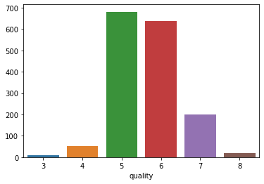

```python
#WIne Quality counts

result = wine_df.groupby(['quality']).size()

#Print the result
print("quality count-per-quality", result)

# plot the result
sns.barplot(x = result.index, y = result.values)
```

[output not shown]

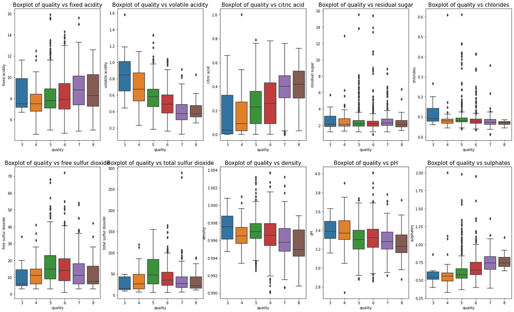

```python
plt.figure(figsize=(25,15))
x_cols = ['fixed acidity', 'volatile acidity', 'citric acid', 'residual sugar', 'chlorides',  'free sulfur dioxide',
          'total sulfur dioxide','density','pH','sulphates','alcohol']
y_cols = ['quality']
for i, col in enumerate(x_cols, start=1):

    plt.subplot(2,5,i)

    title_text = "Boxplot of quality vs "+col
    plt.title(title_text, fontsize=15)

    sns.boxplot(x=wine_df['quality'], y=wine_df[col])
```

1] 4. Do the correlational analysis on the dataset. Provide a visualization for the same. Will this correlational analysis have an effect on feature selection that you will perform in the next step?

```python
The Pearson correlation coefficient measures the linear association between variables.
Its value can be interpreted like so:

+1 - Complete positive correlation
+0.8 - Strong positive correlation
+0.6 - Moderate positive correlation
0 - no correlation whatsoever
-0.6 - Moderate negative correlation
-0.8 - Strong negative correlation
-1 - Complete negative correlation

Incase, two features have very high correlation implies that they are more linearly dependent
and hence have almost the same effect on the dependent variable. So, when two features have high
correlation, we can drop one of the two features. Based on this, the feature selection would be done.
```

```python
from scipy import stats
correlation = wine_df.corr(method='pearson')
print(correlation)
```

```
                      fixed acidity  volatile acidity  citric acid  \
fixed acidity              1.000000         -0.256131     0.671703
volatile acidity          -0.256131          1.000000    -0.552496
citric acid                0.671703         -0.552496     1.000000
residual sugar             0.114777          0.001918     0.143577
chlorides                  0.093705          0.061298     0.203823
free sulfur dioxide       -0.153794         -0.010504    -0.060978
total sulfur dioxide      -0.113181          0.076470     0.035533
density                    0.668047          0.022026     0.364947
pH                        -0.682978          0.234937    -0.541904
sulphates                  0.183006         -0.260987     0.312770
alcohol                   -0.061668         -0.202288     0.109903
quality                    0.124052         -0.390558     0.226373

                      residual sugar  chlorides  free sulfur dioxide  \
fixed acidity               0.114777   0.093705            -0.153794
volatile acidity            0.001918   0.061298            -0.010504
citric acid                 0.143577   0.203823            -0.060978
residual sugar              1.000000   0.055610             0.187049
chlorides                   0.055610   1.000000             0.005562
free sulfur dioxide         0.187049   0.005562             1.000000
total sulfur dioxide        0.203028   0.047400             0.667666
density                     0.355283   0.200632            -0.021946
pH                         -0.085652  -0.265026             0.070377
sulphates                   0.005527   0.371260             0.051658
alcohol                     0.042075  -0.221141            -0.069408
quality                     0.013732  -0.128907            -0.050656

                      total sulfur dioxide   density        pH  sulphates  \
fixed acidity                    -0.113181  0.668047 -0.682978   0.183006
volatile acidity                  0.076470  0.022026  0.234937  -0.260987
citric acid                       0.035533  0.364947 -0.541904   0.312770
residual sugar                    0.203028  0.355283 -0.085652   0.005527
chlorides                         0.047400  0.200632 -0.265026   0.371260
free sulfur dioxide               0.667666 -0.021946  0.070377   0.051658
total sulfur dioxide              1.000000  0.071269 -0.066495   0.042947
density                           0.071269  1.000000 -0.341699   0.148506
pH                               -0.066495 -0.341699  1.000000  -0.196648
sulphates                         0.042947  0.148506 -0.196648   1.000000
alcohol                          -0.205654 -0.496180  0.205633   0.093595
quality                          -0.185100 -0.174919 -0.057731   0.251397

                       alcohol   quality
fixed acidity        -0.061668  0.124052
volatile acidity     -0.202288 -0.390558
citric acid           0.109903  0.226373
residual sugar        0.042075  0.013732
chlorides            -0.221141 -0.128907
free sulfur dioxide  -0.069408 -0.050656
total sulfur dioxide -0.205654 -0.185100
density              -0.496180 -0.174919
pH                    0.205633 -0.057731
sulphates             0.093595  0.251397
alcohol               1.000000  0.476166
quality               0.476166  1.000000
```

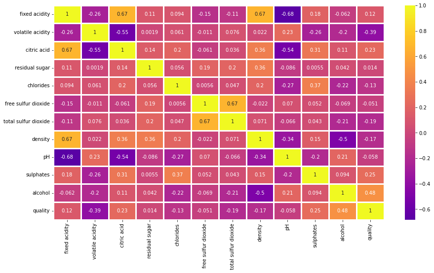

```python
import matplotlib.pyplot as plt

plt.figure(figsize=(15,8))
sns.heatmap(correlation, cmap="plasma",center = 0,linewidths=3,annot=True,
           xticklabels = correlation.columns, yticklabels = correlation.columns)
```

**Incase, two features have very high correlation implies that they are more linearly dependent and hence have almost the same effect on the dependent variable. So, when two features have high correlation, we can drop one of the two features. Based on this, the feature selection would be done.For example:**

1] residual sugar and density have a moderatly positive correlation of 0.36  
2] fixed acidity and density have positive correlation of 0.67  
3] fixed acidity and citric acid have positive correlation of 0.67

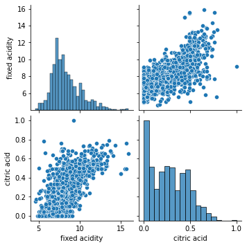

```python
df = wine_df[['fixed acidity','citric acid']]

sns.pairplot(df, kind="scatter")
plt.show()
```

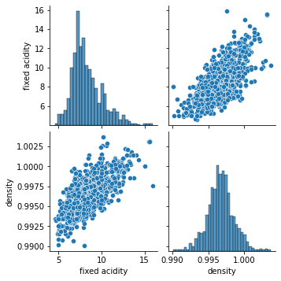

```python
df = wine_df[['fixed acidity','density']]

sns.pairplot(df, kind="scatter")
plt.show()
```

```python
np.corrcoef(wine_df['fixed acidity'], wine_df['density'])
```

```
array([[1.        , 0.66804729],
       [0.66804729, 1.        ]])
```

```python
np.corrcoef(wine_df['fixed acidity'], wine_df['citric acid'])
```

```
array([[1.        , 0.67170343],
       [0.67170343, 1.        ]])
```

2.Data Processing and cleaning

```python
#Check On nulls and determining the %

print("Null Statistics on the entire Data set :\n",wine_df.isna().sum())
print("Null % Statistics on the entire Data set :\n",wine_df.isna().sum()/len(wine_df)*100)
```

```
Null Statistics on the entire Data set :
 fixed acidity           0
volatile acidity        0
citric acid             0
residual sugar          0
chlorides               0
free sulfur dioxide     0
total sulfur dioxide    0
density                 0
pH                      0
sulphates               0
alcohol                 0
quality                 0
dtype: int64
Null % Statistics on the entire Data set :
 fixed acidity           0.0
volatile acidity        0.0
citric acid             0.0
residual sugar          0.0
chlorides               0.0
free sulfur dioxide     0.0
total sulfur dioxide    0.0
density                 0.0
pH                      0.0
sulphates               0.0
alcohol                 0.0
quality                 0.0
dtype: float64
```

```python
#MinMax Normalization on duration column as difference between min and max value for this column was more
from sklearn.preprocessing import MinMaxScaler
import numpy as np
X = np.array(wine_df['total sulfur dioxide']).reshape(-1,1)
scaler = MinMaxScaler()
scaler.fit(X)
X_scaled = scaler.transform(X)
wine_df['total sulfur dioxide'] = X_scaled.reshape(1,-1)[0]
wine_df.head()
```

|  | fixed acidity | volatile acidity | citric acid | residual sugar | chlorides | free sulfur dioxide | total sulfur dioxide | density | pH | sulphates | alcohol | quality |
| --- | --- | --- | --- | --- | --- | --- | --- | --- | --- | --- | --- | --- |
| 0 | 7.4 | 0.70 | 0.00 | 1.9 | 0.076 | 11.0 | 0.098940 | 0.9978 | 3.51 | 0.56 | 9.4 | 5 |
| 1 | 7.8 | 0.88 | 0.00 | 2.6 | 0.098 | 25.0 | 0.215548 | 0.9968 | 3.20 | 0.68 | 9.8 | 5 |
| 2 | 7.8 | 0.76 | 0.04 | 2.3 | 0.092 | 15.0 | 0.169611 | 0.9970 | 3.26 | 0.65 | 9.8 | 5 |
| 3 | 11.2 | 0.28 | 0.56 | 1.9 | 0.075 | 17.0 | 0.190813 | 0.9980 | 3.16 | 0.58 | 9.8 | 6 |
| 4 | 7.4 | 0.70 | 0.00 | 1.9 | 0.076 | 11.0 | 0.098940 | 0.9978 | 3.51 | 0.56 | 9.4 | 5 |

```python
from sklearn.preprocessing import StandardScaler

X = np.array(wine_df['sulphates']).reshape(-1,1)
scaler = StandardScaler()
scaler.fit(X)
X_scaled = scaler.transform(X)
wine_df['sulphates_zscore'] = X_scaled.reshape(1,-1)[0]
wine_df.head()
```

|  | fixed acidity | volatile acidity | citric acid | residual sugar | chlorides | free sulfur dioxide | total sulfur dioxide | density | pH | sulphates | alcohol | quality | sulphates_zscore |
| --- | --- | --- | --- | --- | --- | --- | --- | --- | --- | --- | --- | --- | --- |
| 0 | 7.4 | 0.70 | 0.00 | 1.9 | 0.076 | 11.0 | 0.098940 | 0.9978 | 3.51 | 0.56 | 9.4 | 5 | -0.579207 |
| 1 | 7.8 | 0.88 | 0.00 | 2.6 | 0.098 | 25.0 | 0.215548 | 0.9968 | 3.20 | 0.68 | 9.8 | 5 | 0.128950 |
| 2 | 7.8 | 0.76 | 0.04 | 2.3 | 0.092 | 15.0 | 0.169611 | 0.9970 | 3.26 | 0.65 | 9.8 | 5 | -0.048089 |
| 3 | 11.2 | 0.28 | 0.56 | 1.9 | 0.075 | 17.0 | 0.190813 | 0.9980 | 3.16 | 0.58 | 9.8 | 6 | -0.461180 |
| 4 | 7.4 | 0.70 | 0.00 | 1.9 | 0.076 | 11.0 | 0.098940 | 0.9978 | 3.51 | 0.56 | 9.4 | 5 | -0.579207 |

```python
#MinMax Normalization on suphates column as difference between min and max value for this column was more

from sklearn.preprocessing import MinMaxScaler
import numpy as np
X = np.array(wine_df['sulphates']).reshape(-1,1)
scaler = MinMaxScaler()
scaler.fit(X)
X_scaled = scaler.transform(X)
wine_df['sulphates'] = X_scaled.reshape(1,-1)[0]
wine_df.head()
```

|  | fixed acidity | volatile acidity | citric acid | residual sugar | chlorides | free sulfur dioxide | total sulfur dioxide | density | pH | sulphates | alcohol | quality | sulphates_zscore |
| --- | --- | --- | --- | --- | --- | --- | --- | --- | --- | --- | --- | --- | --- |
| 0 | 7.4 | 0.70 | 0.00 | 1.9 | 0.076 | 11.0 | 0.098940 | 0.9978 | 3.51 | 0.137725 | 9.4 | 5 | -0.579207 |
| 1 | 7.8 | 0.88 | 0.00 | 2.6 | 0.098 | 25.0 | 0.215548 | 0.9968 | 3.20 | 0.209581 | 9.8 | 5 | 0.128950 |
| 2 | 7.8 | 0.76 | 0.04 | 2.3 | 0.092 | 15.0 | 0.169611 | 0.9970 | 3.26 | 0.191617 | 9.8 | 5 | -0.048089 |
| 3 | 11.2 | 0.28 | 0.56 | 1.9 | 0.075 | 17.0 | 0.190813 | 0.9980 | 3.16 | 0.149701 | 9.8 | 6 | -0.461180 |
| 4 | 7.4 | 0.70 | 0.00 | 1.9 | 0.076 | 11.0 | 0.098940 | 0.9978 | 3.51 | 0.137725 | 9.4 | 5 | -0.579207 |

**zscore on sulphate feature was resulting in negative value ( can be seen in column :sulphates_zscore), hence normalization using min-max method is used </b1>**

```python
# removing unwanted data set after chi and pearson test

wine_drop_df= wine_df.drop(['total sulfur dioxide'],axis=1)
wine_drop_df= wine_drop_df.drop(['residual sugar'],axis=1)

wine_drop_df.head()
```

|  | fixed acidity | volatile acidity | citric acid | chlorides | free sulfur dioxide | density | pH | sulphates | alcohol | quality | sulphates_zscore |
| --- | --- | --- | --- | --- | --- | --- | --- | --- | --- | --- | --- |
| 0 | 7.4 | 0.70 | 0.00 | 0.076 | 11.0 | 0.9978 | 3.51 | 0.137725 | 9.4 | 5 | -0.579207 |
| 1 | 7.8 | 0.88 | 0.00 | 0.098 | 25.0 | 0.9968 | 3.20 | 0.209581 | 9.8 | 5 | 0.128950 |
| 2 | 7.8 | 0.76 | 0.04 | 0.092 | 15.0 | 0.9970 | 3.26 | 0.191617 | 9.8 | 5 | -0.048089 |
| 3 | 11.2 | 0.28 | 0.56 | 0.075 | 17.0 | 0.9980 | 3.16 | 0.149701 | 9.8 | 6 | -0.461180 |
| 4 | 7.4 | 0.70 | 0.00 | 0.076 | 11.0 | 0.9978 | 3.51 | 0.137725 | 9.4 | 5 | -0.579207 |

**2c Handling Outliers**

**Transforming all outlier values of chlordies feature to Null**

```python
import numpy as np
for x in ['chlorides']:
    q75,q25 = np.percentile(wine_drop_df.loc[:,x],[75,25])
    intr_qr = q75-q25

    max = q75+(1.5*intr_qr)
    min = q25-(1.5*intr_qr)

    wine_drop_df.loc[wine_drop_df[x] < min,x] = np.nan
    wine_drop_df.loc[wine_drop_df[x] > max,x] = np.nan
```

**Transforming all outlier values of fixed acidity feature to Null**

```python
for x in ['fixed acidity']:
    q75,q25 = np.percentile(wine_drop_df.loc[:,x],[75,25])
    intr_qr = q75-q25

    max = q75+(1.5*intr_qr)
    min = q25-(1.5*intr_qr)

    wine_drop_df.loc[wine_drop_df[x] < min,x] = np.nan
    wine_drop_df.loc[wine_drop_df[x] > max,x] = np.nan
```

```python
#Check On nulls and determining the %

print("Null Statistics on the entire Data set :\n",wine_drop_df.isna().sum())
print("Null % Statistics on the entire Data set :\n",wine_drop_df.isna().sum()/len(wine_drop_df)*100)
```

```
Null Statistics on the entire Data set :
 fixed acidity           49
volatile acidity         0
citric acid              0
chlorides              112
free sulfur dioxide      0
density                  0
pH                       0
sulphates                0
alcohol                  0
quality                  0
sulphates_zscore         0
dtype: int64
Null % Statistics on the entire Data set :
 fixed acidity          3.064415
volatile acidity       0.000000
citric acid            0.000000
chlorides              7.004378
free sulfur dioxide    0.000000
density                0.000000
pH                     0.000000
sulphates              0.000000
alcohol                0.000000
quality                0.000000
sulphates_zscore       0.000000
dtype: float64
```

**Transforming : replacing outliers values for Features clorides and fixed acidity by mean value by imputing**

```python
#filling missing vaues by mean

import numpy as np
from sklearn.impute import SimpleImputer

preprocessor = SimpleImputer(missing_values=np.nan, strategy='mean')
X = np.array(wine_drop_df['chlorides']).reshape(-1,1)
preprocessor.fit(X)
X_prep = preprocessor.transform(X)
wine_drop_df['chlorides_variate'] = X_prep.reshape(1,-1)[0]
wine_drop_df.head()

preprocessor = SimpleImputer(missing_values=np.nan, strategy='mean')
X = np.array(wine_drop_df['fixed acidity']).reshape(-1,1)
preprocessor.fit(X)
X_prep = preprocessor.transform(X)
wine_drop_df['fixed_acidity_variate'] = X_prep.reshape(1,-1)[0]
wine_drop_df.head()
```

|  | fixed acidity | volatile acidity | citric acid | chlorides | free sulfur dioxide | density | pH | sulphates | alcohol | quality | sulphates_zscore | chlorides_variate | fixed_acidity_variate |
| --- | --- | --- | --- | --- | --- | --- | --- | --- | --- | --- | --- | --- | --- |
| 0 | 7.4 | 0.70 | 0.00 | 0.076 | 11.0 | 0.9978 | 3.51 | 0.137725 | 9.4 | 5 | -0.579207 | 0.076 | 7.4 |
| 1 | 7.8 | 0.88 | 0.00 | 0.098 | 25.0 | 0.9968 | 3.20 | 0.209581 | 9.8 | 5 | 0.128950 | 0.098 | 7.8 |
| 2 | 7.8 | 0.76 | 0.04 | 0.092 | 15.0 | 0.9970 | 3.26 | 0.191617 | 9.8 | 5 | -0.048089 | 0.092 | 7.8 |
| 3 | 11.2 | 0.28 | 0.56 | 0.075 | 17.0 | 0.9980 | 3.16 | 0.149701 | 9.8 | 6 | -0.461180 | 0.075 | 11.2 |
| 4 | 7.4 | 0.70 | 0.00 | 0.076 | 11.0 | 0.9978 | 3.51 | 0.137725 | 9.4 | 5 | -0.579207 | 0.076 | 7.4 |

3. Decision tree Model Building Building Predicting Models and Evaluating the model

```python
X=wine_drop_df[[ 'fixed_acidity_variate','citric acid','chlorides_variate','density','volatile acidity','sulphates','alcohol' ]]
#X= wine_drop_df[['fixed acidity', 'volatile acidity', 'citric acid', 'chlorides',  'free sulfur dioxide','density','pH','sulphates','alcohol']]
y=wine_drop_df['quality']
print(X.shape)
print(y.shape)
```

```
(1599, 7)
(1599,)
```

```python
from sklearn.model_selection import train_test_split
X_train,X_test,y_train,y_test=train_test_split(X,y,test_size=0.02)
print(X_train.shape,y_train.shape)
print(X_test.shape,y_test.shape)
```

```
(1567, 7) (1567,)
(32, 7) (32,)
```

**DecisionTreeRegressor Model Fit**

```python
from sklearn.tree import DecisionTreeRegressor

# create a regressor object
regressor = DecisionTreeRegressor(random_state = 0)

# fit the regressor with X and Y data
regressor.fit(X_train, y_train)
```

```
DecisionTreeRegressor(random_state=0)
```

**Predicted values**

```python
# predicting a new value
from sklearn.model_selection import cross_val_score
# test the output by changing values, like 3750
y_pred = regressor.predict(X_test)

# print the predicted price
print("Predicted Quality: n", y_pred)
```

```
Predicted Quality: n [4. 5. 5. 6. 5. 5. 6. 5. 5. 5. 6. 6. 5. 6. 6. 5. 5. 5. 5. 6. 7. 5. 6. 6.
 5. 6. 6. 6. 6. 5. 5. 5.]
```

```python
cross_val_score(regressor, X_train, y_train, cv=10)
```

```
array([-0.07521764, -0.06355462, -0.23531798,  0.15325415,  0.01992296,
       -0.01904422,  0.15524934,  0.08637009,  0.1328954 ,  0.29466927])
```

```python
cross_val_score(regressor, X_test, y_test, cv=10)
```

```
array([-7. , -3. , -2. ,  0. ,  1. , -0.5,  0.5,  1. , -6.5, -0.5])
```

**Decision Classifier model fit**

```python
from sklearn.preprocessing import StandardScaler
sc = StandardScaler()

# providing the inputs for the scalling purpose
X_train = sc.fit_transform(X_train)
X_test = sc.transform(X_test)
```

```python
from sklearn.tree import DecisionTreeClassifier

# entropy means information gain
classifer = DecisionTreeClassifier(criterion='entropy', random_state=0)

# providing the training dataset
classifer.fit(X_train,y_train)
```

```
DecisionTreeClassifier(criterion='entropy', random_state=0)
```

```python
y_pred = classifer.predict(X_test)
```

**Accuracy for Decision Classifier model**

```python
from sklearn.metrics import accuracy_score

# accuracy
accuracy_score(y_pred,y_test)
```

```
0.71875
```

**3a. Plotting Decision tree for Training data set**

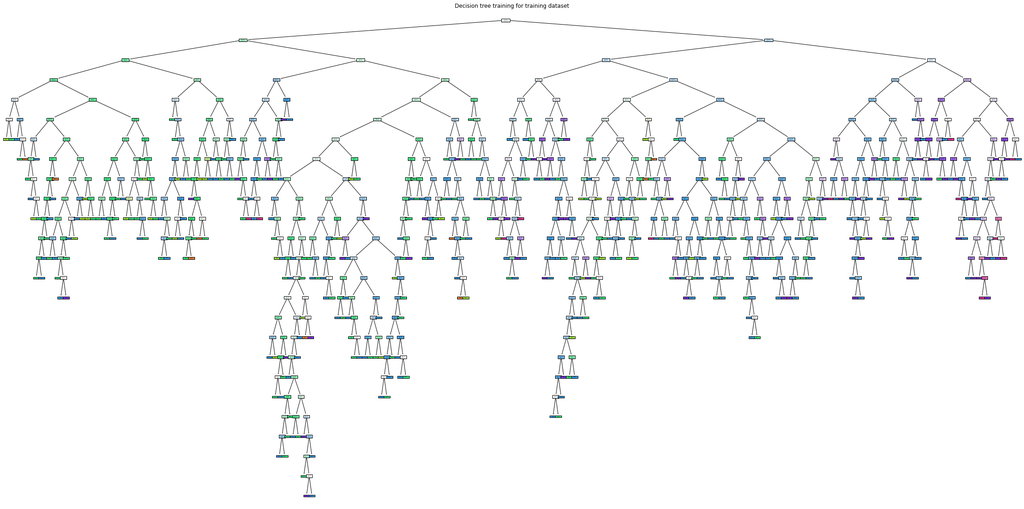

```python
from sklearn.tree import DecisionTreeClassifier, plot_tree
clf = DecisionTreeClassifier()

# output size of decision tree
plt.figure(figsize=(40,20))

# providing the training dataset
clf = clf.fit(X_train, y_train)
plot_tree(clf, filled=True)
plt.title("Decision tree training for training dataset")
plt.show()
```

**3b. Plotting Decision tree for test data set**

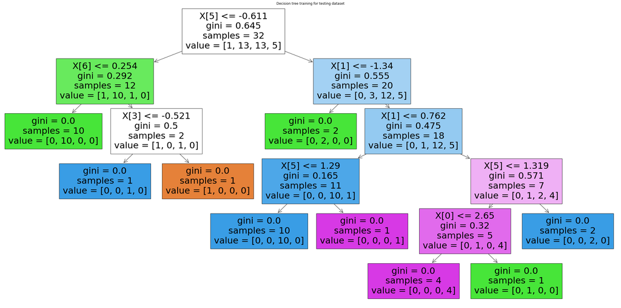

```python
from sklearn.tree import DecisionTreeClassifier, plot_tree
clf = DecisionTreeClassifier()

# output size of decision tree
plt.figure(figsize=(40,20))

# providing the training dataset
clf = clf.fit(X_test, y_test)
plot_tree(clf, filled=True)
plt.title("Decision tree training for testing dataset")
plt.show()
```

**3c. Plotting Decision tree as text tree**

```python
# importing the tree
from sklearn import tree

# text based tree
text_representation = tree.export_text(clf)
print(text_representation)
```

```
|--- feature_5 <= -0.61
|   |--- feature_6 <= 0.25
|   |   |--- class: 5
|   |--- feature_6 >  0.25
|   |   |--- feature_3 <= -0.52
|   |   |   |--- class: 6
|   |   |--- feature_3 >  -0.52
|   |   |   |--- class: 4
|--- feature_5 >  -0.61
|   |--- feature_1 <= -1.34
|   |   |--- class: 5
|   |--- feature_1 >  -1.34
|   |   |--- feature_1 <= 0.76
|   |   |   |--- feature_5 <= 1.29
|   |   |   |   |--- class: 6
|   |   |   |--- feature_5 >  1.29
|   |   |   |   |--- class: 7
|   |   |--- feature_1 >  0.76
|   |   |   |--- feature_5 <= 1.32
|   |   |   |   |--- feature_0 <= 2.65
|   |   |   |   |   |--- class: 7
|   |   |   |   |--- feature_0 >  2.65
|   |   |   |   |   |--- class: 5
|   |   |   |--- feature_5 >  1.32
|   |   |   |   |--- class: 6
```

**3d. confusion dataset for Decision tree**

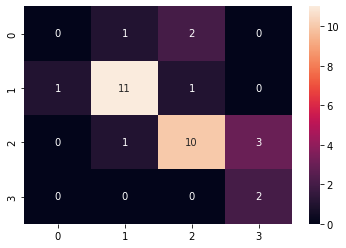

```python
import matplotlib.pyplot as plt
from sklearn.metrics import confusion_matrix, ConfusionMatrixDisplay

cm = confusion_matrix(y_test,y_pred)

# Making the Confusion Matrix
cm = confusion_matrix(y_pred, y_test)
sns.heatmap(cm,annot=True)
```